# Probability Distributions

Joe Ornstein

9/15/2021

# What is a probability distribution?

A **probability distribution** assigns a number from 0 to 1 to every possible value that a variable can take. All of the values in the distribution must sum to 1.

To illustrate, let’s look the CES:

```r
library(tidyverse)
library(here)

load(
  here('data/ces-2020/cleaned-CES.RData')
)
```

## Discrete Variables

Discrete variables can take only a given set of values.

Binary variables are a special type of discrete variable that only takes 2 values.

```r
ces %>%
  count(gender) %>%
  # probability is the total number of people in a category divided by the total number of people in all categories
  mutate(probability = n / sum(n))
```

```
## # A tibble: 2 x 3
##   gender     n probability
##   <chr>  <int>       <dbl>
## 1 Female 35209       0.577
## 2 Male   25791       0.423
```

Each probability value tells you - if you were to draw a survey respondent at random - what’s the chance they would be female or male?

## Categorical Variables

Categorical variables are a discrete variable that could take multiple values.

```r
ces %>%
  count(race) %>%
  mutate(probability = n / sum(n))
```

```
## # A tibble: 5 x 3
##   race         n probability
##   <chr>    <int>       <dbl>
## 1 Asian     1831      0.0300
## 2 Black     6952      0.114
## 3 Hispanic  5180      0.0849
## 4 Other     2909      0.0477
## 5 White    44128      0.723
```

## Ordinal Variables

An ordinal variable is a categorical variable, but there is some ordering. We know the order, but not the relative distances between the values.

```r
ces %>%
  filter(!is.na(trump_approval)) %>%
  count(trump_approval) %>%
  mutate(probability = n / sum(n))
```

```
## # A tibble: 5 x 3
##   trump_approval          n probability
##   <fct>               <int>       <dbl>
## 1 Strongly disapprove 31927      0.524
## 2 Somewhat disapprove  4213      0.0691
## 3 Not sure             1464      0.0240
## 4 Somewhat approve     8615      0.141
## 5 Strongly approve    14749      0.242
```

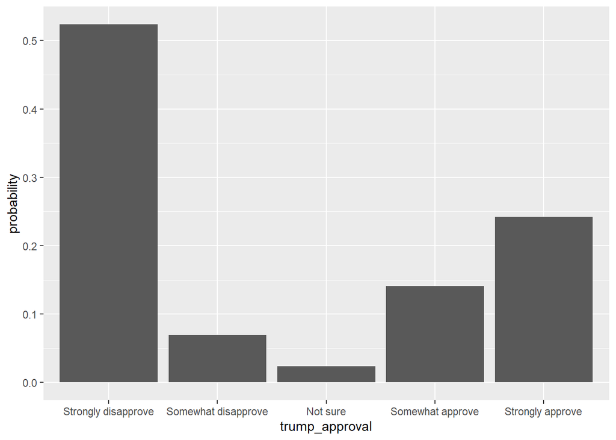

```r
# plot that
ces %>%
  filter(!is.na(trump_approval)) %>%
  count(trump_approval) %>%
  mutate(probability = n / sum(n)) %>%
  ggplot(mapping = aes(x = trump_approval, y = probability)) +
  geom_col()
```

## Continuous Variables

A continuous variable could, in principle, take any numeric value.

```r
# *could* do it this way
ces %>%
  count(age) %>%
  mutate(probability = n / sum(n))
```

```
## # A tibble: 78 x 3
##      age     n probability
##    <dbl> <int>       <dbl>
##  1    18   584     0.00957
##  2    19   618     0.0101
##  3    20  1144     0.0188
##  4    21   916     0.0150
##  5    22   878     0.0144
##  6    23   879     0.0144
##  7    24   940     0.0154
##  8    25  1124     0.0184
##  9    26  1056     0.0173
## 10    27  1168     0.0191
## # ... with 68 more rows
```

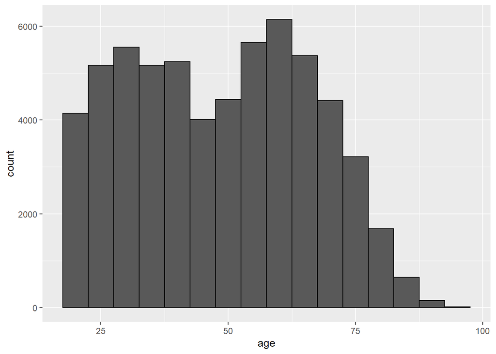

```r
# instead of computing the probability in each category, we typically summarize by binning values together
ggplot(data = ces,
       mapping = aes(x = age)) +
  geom_histogram(color = 'black',
                 binwidth = 5)
```

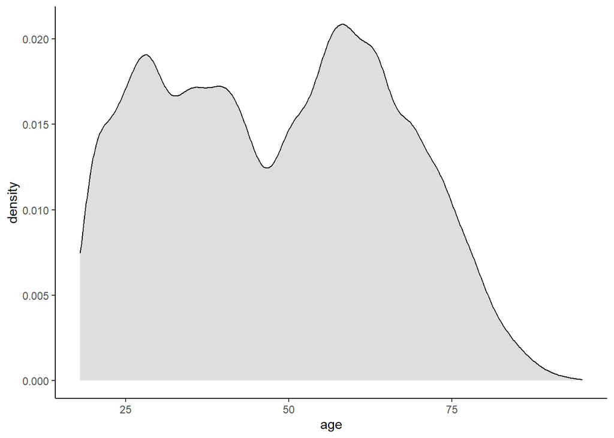

```r
# instead of a histogram, you could use a density plot
ggplot(data = ces,
       mapping = aes(x = age)) +
  geom_density(alpha = 0.5, fill = 'gray') +
  theme_classic()
```

# Joint Distributions

```r
joint_distribution <- ces %>%
  count(gender, educ) %>%
  mutate(probability = n / sum(n))

sum(joint_distribution$probability)
```

```
## [1] 1
```

Joint probability: $P(A, B)$

Probability of observing (in the CES) a female with a 2-year degree: $P(female, 2 year) = 0.0635$.

# Conditional Probability

If joint probability told us the probability of observing someone who is female *and* has a two year degree…

Conditional probability tells us the probability that *if* we observe someone who has a 2-year degree, what’s the chance they’re a female? Or, conversely, *if* we observe a female, what’s the chance she has a two-year degree?

The way we denote conditional probability is with a vertical bar:

$P(A|B)$

And it’s related to joint probability this way:

$P(A|B) = P(A, B) / P(B)$

```r
# P(educ | gender)
conditional_probability1 <- ces %>%
  group_by(gender, educ) %>%
  summarize(freq = n()) %>%
  mutate(conditional_probability = freq / sum(freq))

conditional_probability1
```

```
## # A tibble: 12 x 4
## # Groups:   gender [2]
##    gender educ                  freq conditional_probability
##    <chr>  <chr>                <int>                   <dbl>
##  1 Female 2-year                3872                  0.110
##  2 Female 4-year                7482                  0.213
##  3 Female High school graduate 10721                  0.304
##  4 Female No HS                 1305                  0.0371
##  5 Female Post-grad             4158                  0.118
##  6 Female Some college          7671                  0.218
##  7 Male   2-year                2667                  0.103
##  8 Male   4-year                6670                  0.259
##  9 Male   High school graduate  5897                  0.229
## 10 Male   No HS                  678                  0.0263
## 11 Male   Post-grad             4220                  0.164
## 12 Male   Some college          5659                  0.219
```

```r
# P(gender | educ)
conditional_probability2 <- ces %>%
  group_by(educ, gender) %>%
  summarize(freq = n()) %>%
  mutate(conditional_probability = freq / sum(freq))

conditional_probability2
```

```
## # A tibble: 12 x 4
## # Groups:   educ [6]
##    educ                 gender  freq conditional_probability
##    <chr>                <chr>  <int>                   <dbl>
##  1 2-year               Female  3872                   0.592
##  2 2-year               Male    2667                   0.408
##  3 4-year               Female  7482                   0.529
##  4 4-year               Male    6670                   0.471
##  5 High school graduate Female 10721                   0.645
##  6 High school graduate Male    5897                   0.355
##  7 No HS                Female  1305                   0.658
##  8 No HS                Male     678                   0.342
##  9 Post-grad            Female  4158                   0.496
## 10 Post-grad            Male    4220                   0.504
## 11 Some college         Female  7671                   0.575
## 12 Some college         Male    5659                   0.425
```

## Bayes Rule

$P(A|B)$ is not the same as $P(B|A)$, but if you know one you can compute the other.

Bayes Rule: $P(A|B) = P(B|A) * P(A) / P(B)$

Probability that I’m infected with COVID-19 if I get a positive COVID-19 test.

P(positive test | COVID) = 0.9

P(COVID) = 0.01

P(positive test) = 0.01 * 0.9 + 0.99 * 0.05 = 0.0585

P(COVID | positive test) = 0.9 * 0.01 / 0.0585 = roughly 15%